# Лабораторная работа №7

Архитектура компьютера

## Докладчик

- Володина Алиса Алексеевна
- НКАбд-01-25
- Российский университет дружбы народов им. П. Лумумбы
- 1032253521

# Цель работы

Ознакомление с файловой системой Linux, её структурой, именами и содержанием каталогов. Приобретение практических навыков по применению команд для работы с файлами и каталогами, по управлению процессами (и работами), по проверке использования диска и обслуживанию файловой системы.

# Задания

1. Выполните все примеры, приведённые в первой части описания лабораторной работы.
2. Выполните следующие действия, зафиксировав в отчёте по лабораторной работе используемые при этом команды и результаты их выполнения:
3. Определите опции команды chmod, необходимые для того, чтобы присвоить перечис- ленным ниже файлам выделенные права доступа, считая, что в начале таких прав нет:
4. Проделайте приведённые ниже упражнения, записывая в отчёт по лабораторной работе используемые при этом команды:
5. Прочитайте man по командам mount, fsck, mkfs, kill и кратко их охарактеризуйте, приведя примеры.

# Теоретическое введение

Файловая система в Linux состоит из фалов и каталогов. Каждому физическому носителю соответствует своя файловая система. Существует несколько типов файловых систем. Перечислим наиболее часто встречающиеся типы: – ext2fs (second extended filesystem); – ext2fs (third extended file system); – ext4 (fourth extended file system); – ReiserFS; – xfs; – fat (file allocation table); – ntfs (new technology file system). Для просмотра используемых в операционной системе файловых систем можно воспользоваться командой mount без параметров.

## Выполнение лабораторной работы

## 1. Выполните все примеры, приведённые в первой части описания лабораторной работы

Копирование файла в текущем каталоге. Скопировать файл ~/abc1 в файл april и в файл may:

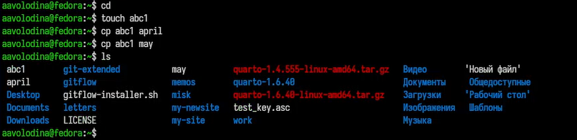

Рисунок 1: Копирование файла в текущем каталоге

## 2. Копирование нескольких файлов в каталог. Скопировать файлы april и may в каталог

monthly

## 3. Копирование файлов в произвольном каталоге. Скопировать файл monthly/may в файл

с именем june:

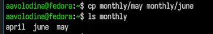

Рисунок 3: Копирование файлов в произвольном каталоге

## 1. Копирование каталогов в текущем каталоге. Скопировать каталог monthly в каталог

monthly.00:

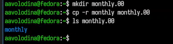

Рисунок 4: Копирование каталогов в текущем каталоге

## 2. Копирование каталогов в произвольном каталоге. Скопировать каталог monthly.00

в каталог /tmp

## 1. Переименование файлов в текущем каталоге. Изменить название файла april на

july в домашнем каталоге:

## 3. Переименование каталогов в текущем каталоге. Переименовать каталог monthly.00

в monthly.01

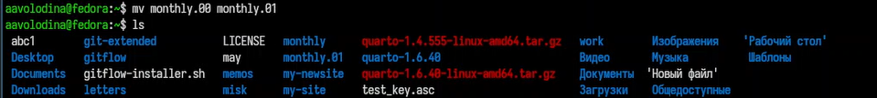

Рисунок 8: Переименовать каталог monthly.00 в monthly.01

## 4. Перемещение каталога в другой каталог. Переместить каталог monthly.01 в каталог

reports:

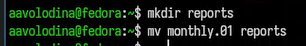

Рисунок 9: Переместить каталог monthly.01в каталог reports

## 5. Переименование каталога, не являющегося текущим. Переименовать каталог reports/monthly.01 в reports/monthly

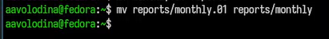

Рисунок 10: Переименовать каталог reports/monthly.01 в reports/monthly

## 1. Требуется создать файл ~/may с правом выполнения для владельца, требуется лишить владельца файла ~/may права на выполнение

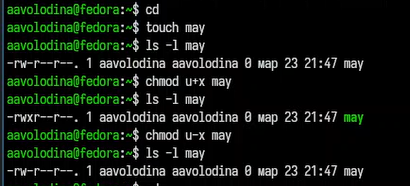

Рисунок 11: права доступа

## 2. Требуется создать каталог monthly с запретом на чтение для членов группы и всех

остальных пользователей:

## 1. Для определения объёма свободного пространства на файловой системе можно воспользоваться командой df

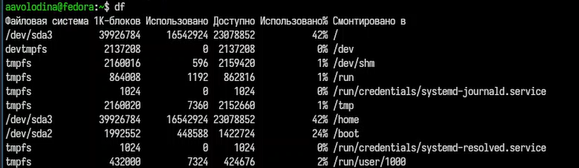

Рисунок 14: df

## 2. С помощью команды fsck можно проверить (а в ряде случаев восстановить) целостность файловой системы

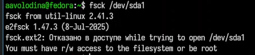

Рисунок 15: fsck

## Выполните следующие действия, зафиксировав в отчёте по лабораторной работе используемые при этом команды и результаты их выполнения:

## Переименуйте файл ~/ski.plases/equipment в ~/ski.plases/equiplist.

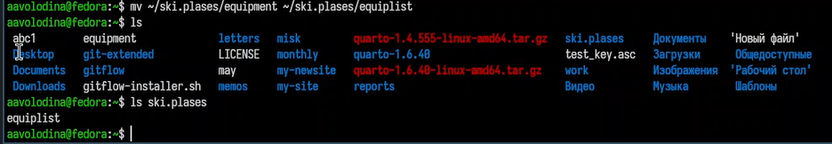

Рисунок 19: mv ~/ski.plases/equipment ~/ski.plases/equiplist

## Создайте в домашнем каталоге файл abc1 и скопируйте его в каталог ~/ski.plases, назовите его equiplist2

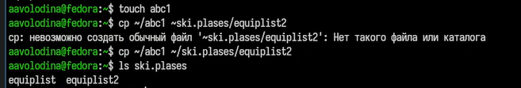

Рисунок 20: touch abc1

## Переместите файлы ~/ski.plases/equiplist и equiplist2 в каталог ~/ski.plases/equipment

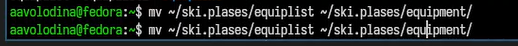

Рисунок 22: mv ~/ski.plases/equiplist ~/ski.plases/equipment

## Создайте и переместите каталог ~/newdir в каталог ~/ski.plases и назовите его plans.

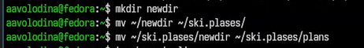

Рисунок 23: mkdir newdir

## 3. Определите опции команды chmod, необходимые для того, чтобы присвоить перечисленным ниже файлам выделенные права доступа, считая, что в начале таких прав нет:

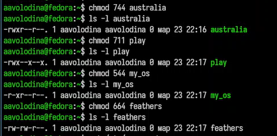

Рисунок 24: chmod

## 4. Проделайте приведённые ниже упражнения, записывая в отчёт по лабораторной

работе используемые при этом команды

## Просмотрите содержимое файла /etc/password.

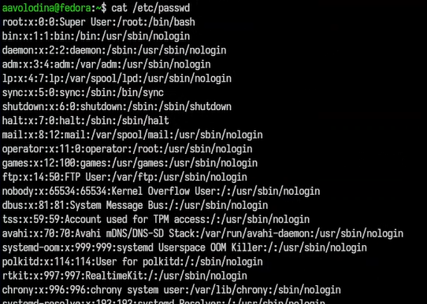

## Переместите файл ~/file.old в каталог ~/play

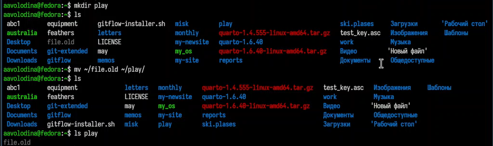

Рисунок 27: mv ~/file.old ~/play

## Скопируйте каталог ~/play в каталог ~/fun

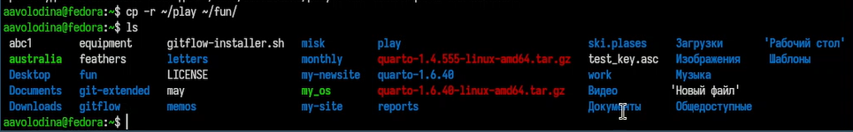

Рисунок 28: cp -r ~/play ~/fun

## Переместите каталог ~/fun в каталог ~/play и назовите его games.

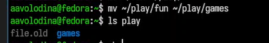

Рисунок 29: mv ~/play/fun ~/play/games

## Дайте владельцу файла ~/feathers права на чтение (рис. 32).

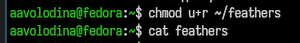

Рисунок 32: chmod u+r ~/feathers

## Мы не можем перейти в каталог play поскольку лишили владельца прав на выполнение

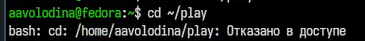

Рисунок 34: cd play

## Выводы

Мы ознакомились с файловой системой Linux, её структурой, именами и содержанием каталогов. Приобрели практические навыки по применению команд для работы с файлами и каталогами, по управлению процессами (и работами), по проверке использования диска и обслуживанию файловой системы.